# Candidate heterochrony and network context

Clique-resolved annual-perennial rewiring in Pooideae

Published

September 14, 2026

**Interpretation boundary**

Positive phase values mean later deployment in annuals on the matched five-point sampling axis. They do not prove delayed developmental stage: the samples lack an independent meristem-stage clock. Candidate selection also used these expression data, so this is a conditional exploratory screen, not a confirmatory significance analysis.

28

candidate HOGs

26

recurrent candidate-tissue shifts

11

coordinated anchor/module shifts

24

later annual profiles

2

earlier annual profiles

## Strongest recurrent shifts

The primary phase statistic is an expression-weighted centroid on a normalized axis from 0 (T1) to 1 (T5). One sampling interval is 0.25 units. The table is sortable and searchable.

Candidate heterochrony calls

Ranked by evidence pattern and absolute anchor phase shift

| HOG | Tissue | Evidence pattern | Direction | Δ phase (intervals) | Anchor pairs | Bootstrap support | Module Δ phase | Annotation |
| --- | --- | --- | --- | --- | --- | --- | --- | --- |
| HOG:0032765 | leaf | Coordinated anchor + module | Annual later | 0.899351220847244 | 3 | 1 | 0.238542491085496 | Zinc finger, C3HC4 type (RING finger) fam… |
| HOG:0011541 | leaf | Coordinated anchor + module | Annual later | 0.798359633670908 | 3 | 1 | 0.190016094991329 | transcription regulatory protein SNF2, pu… |
| HOG:0006131 | leaf | Coordinated anchor + module | Annual later | 0.729687789561132 | 3 | 0.957915831663327 | 0.146628948628073 | DNA-binding bromodomain-containing protein |
| HOG:0025149 | leaf | Coordinated anchor + module | Annual later | 0.69504341012796 | 3 | 0.991983967935872 | 0.171989916113456 | chromatin remodeling 4 |
| HOG:0027918 | root | Coordinated anchor + module | Annual later | 0.63545846596034 | 4 | 0.929859719438878 | 0.119113351180148 | nucleic acid binding;zinc ion binding;DNA… |
| HOG:0025923 | root | Coordinated anchor + module | Annual later | 0.587362411469688 | 4 | 0.983967935871743 | 0.132734933522331 | Pre-mRNA-processing-splicing factor |
| HOG:0005857 | leaf | Coordinated anchor + module | Annual later | 0.561699272795324 | 3 | 1 | 0.167383326892214 | SET domain protein 2 |
| HOG:0026838 | leaf | Coordinated anchor + module | Annual later | 0.55839155547078 | 3 | 0.887775551102204 | 0.186312021793503 | (1 of 1) PTHR15922:SF2 - NEUROBLASTOMA-AM… |
| HOG:0027421 | root | Coordinated anchor + module | Annual later | 0.547408337517556 | 4 | 0.94188376753507 | 0.130798901186307 | GYF domain-containing protein |
| HOG:0010481 | root | Coordinated anchor + module | Annual later | 0.527896116402436 | 4 | 0.927855711422846 | 0.117778260756622 | Helicase/SANT-associated, DNA binding pro… |

[output cut: 16 more lines]

Pair support is out of four sister pairs. Positive phase means later annual deployment.

**A carotenoid-to-strigolactone candidate**

`HOG:0026234` is the ζ-carotene desaturase represented by [`Bradi1g54390`](https://phytozome-next.jgi.doe.gov/report/gene/Bdistachyon_v3_2/Bradi1g54390). It supplies the carotenoid pathway that produces β-carotene, the upstream substrate from which D27, CCD7/MAX3, and CCD8/MAX4 initiate strigolactone biosynthesis. Its signal should therefore be interpreted as potential **carotenoid precursor allocation**, not as a strigolactone-specific enzymatic step. In this screen the candidate transcript itself does not show a strong root phase shift, but its recurrent module shifts later in annuals (`Δ phase = 0.205`, 4/4 sister pairs). This is compatible with altered timing of a carotenoid-derived hormone program and merits targeted examination alongside D27, CCD7, CCD8, and MAX1 orthologues ([Alder et al. 2012](https://doi.org/10.1126/science.1218094)).

## Distribution across tissues

**Candidate-level timing summaries by tissue**

| **Characteristic** | **leaf** N = 28<sup>1</sup> | **root** N = 28<sup>1</sup> | **Overall** N = 56<sup>1</sup> |
| --- | --- | --- | --- |
| Evidence pattern |  |  |  |
| Anchor only | 3 (11%) | 4 (14%) | 7 (13%) |
| Coordinated anchor + module | 7 (25%) | 4 (14%) | 11 (20%) |
| Module only | 5 (18%) | 3 (11%) | 8 (14%) |
| No recurrent shift | 13 (46%) | 17 (61%) | 30 (54%) |
| Anchor phase shift | 0.29 (-0.09, 0.49) | 0.31 (0.11, 0.47) | 0.31 (0.03, 0.49) |
| Pair agreement |  |  |  |
| 2 | 7 (25%) | 6 (21%) | 13 (23%) |
| 3 | 18 (64%) | 14 (50%) | 32 (57%) |
| 4 | 3 (11%) | 8 (29%) | 11 (20%) |
| Bootstrap support | 0.88 (0.81, 0.97) | 0.86 (0.69, 0.93) | 0.87 (0.80, 0.94) |
| Module phase shift | 0.12 (0.01, 0.17) | 0.10 (0.01, 0.12) | 0.10 (0.01, 0.14) |

<sup>1</sup> n (%); Median (Q1, Q3)

## Expression-profile atlas

Thin lines are individual species; thick lines are life-history means. Values are robustly standardized within each species and therefore describe deployment shape rather than absolute cross-species transcript abundance. Solid lines represent the clique-resolved candidate gene and dashed lines its recurrent local module.

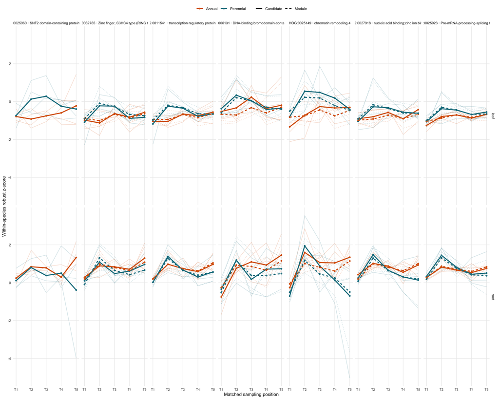

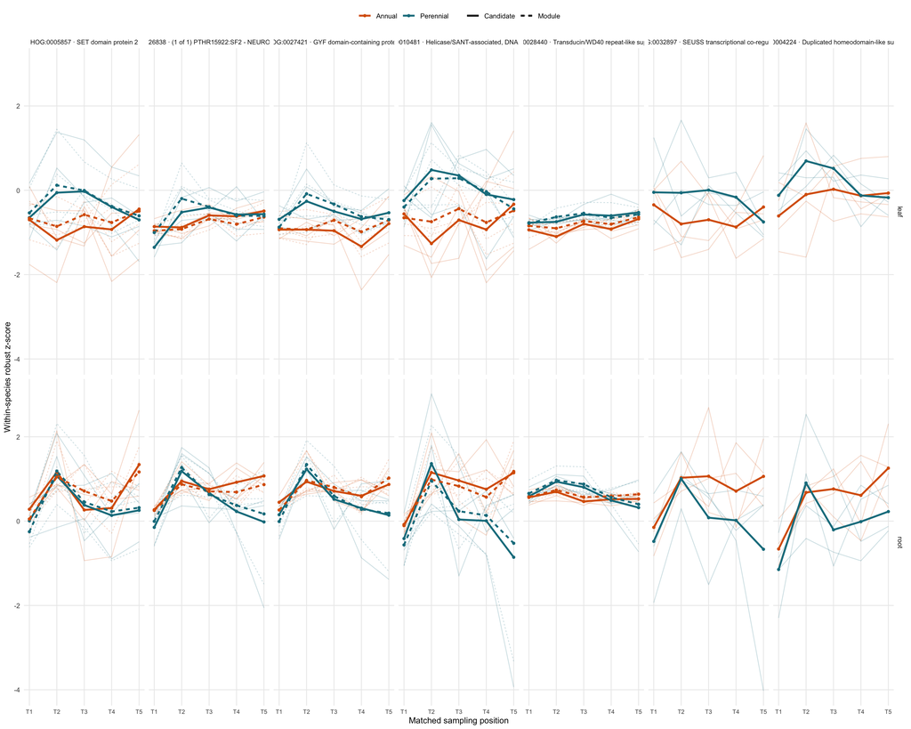

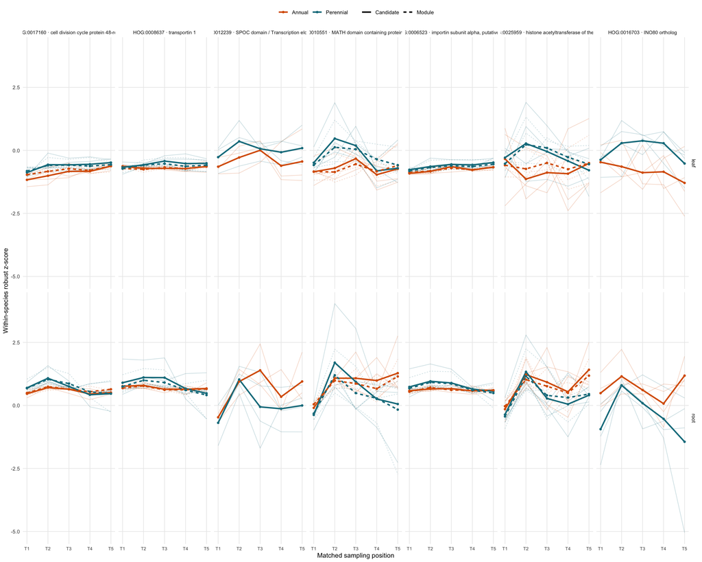

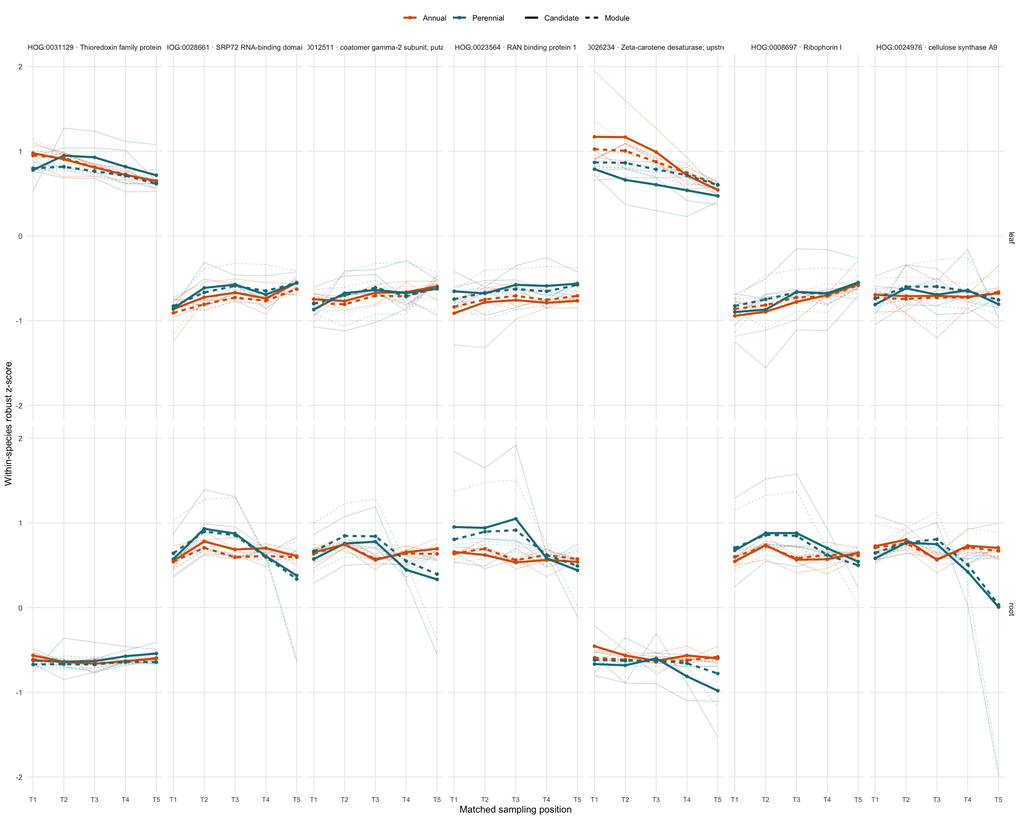

## Annual and perennial ego-networks

These views hold each candidate anchor fixed and count in how many annual or perennial species each recurrent HOG is an immediate network neighbour. They show neighbour recruitment, not regulation direction and not edges among neighbours.

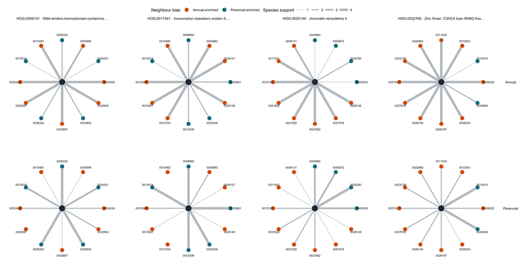

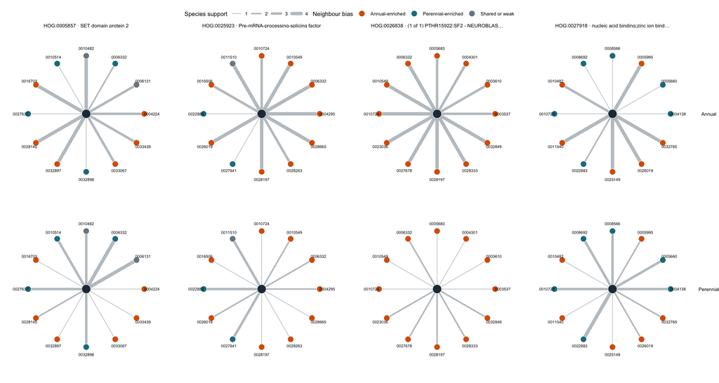

### Sortable ego-network evidence

| Candidate | Neighbour HOG | Annual support | Perennial support | Δ support | Bias |
| --- | --- | --- | --- | --- | --- |
| HOG:0005857 | HOG:0016703 | 4 | 1 | 3 | Annual-enriched |
| HOG:0005857 | HOG:0032897 | 4 | 1 | 3 | Annual-enriched |
| HOG:0005857 | HOG:0006332 | 2 | 4 | -2 | Perennial-enriched |
| HOG:0005857 | HOG:0028145 | 4 | 2 | 2 | Annual-enriched |
| HOG:0005857 | HOG:0004224 | 3 | 1 | 2 | Annual-enriched |
| HOG:0005857 | HOG:0010514 | 1 | 3 | -2 | Perennial-enriched |
| HOG:0005857 | HOG:0027637 | 1 | 3 | -2 | Perennial-enriched |
| HOG:0005857 | HOG:0032898 | 1 | 3 | -2 | Perennial-enriched |
| HOG:0005857 | HOG:0033067 | 3 | 1 | 2 | Annual-enriched |
| HOG:0005857 | HOG:0033439 | 3 | 1 | 2 | Annual-enriched |

[output cut: 86 more lines]

## Annotation and external evidence

Database links are provided only when the corresponding identifier is available. An OrthoDB search link is retained for every candidate HOG.

| HOG | B. distachyon | UniProt | OrthoDB | Signal | Regulator | Resolved annotation | Orthology | Literature | Interpretation |
| --- | --- | --- | --- | --- | --- | --- | --- | --- | --- |
| HOG:0011541 | [Bradi3g01297](https://phytozome-next.jgi.doe.gov/report/gene/Bdistachyon_v3_2/Bradi3g01297) | [A0A0Q3PTS7](https://www.uniprot.org/uniprotkb/A0A0Q3PTS7/entry) | [402030at33090](https://www.orthodb.org/?query=402030at33090) | annual | True | BRAHMA SWI/SNF ATPase | strong probable one-to-one orthologue | [DOI](https://doi.org/10.1242/dev.01363) | Strong direct flowering and meristem evidence in Arabidopsis |
| HOG:0025149 | [Bradi1g26940](https://phytozome-next.jgi.doe.gov/report/gene/Bdistachyon_v3_2/Bradi1g26940) | [A0A0Q3JDT3](https://www.uniprot.org/uniprotkb/A0A0Q3JDT3/entry) | [609528at33090](https://www.orthodb.org/?query=609528at33090) | annual | True | CHR4/PKR1 chromatin remodeler | strong probable one-to-one orthologue | [DOI](https://doi.org/10.1105/tpc.19.00992) | Strong direct floral-transition and meristem evidence in Arabidopsis |
| HOG:0027918 | [Bradi4g35977](https://phytozome-next.jgi.doe.gov/report/gene/Bdistachyon_v3_2/Bradi4g35977) | [A0A0Q3EUI2](https://www.uniprot.org/uniprotkb/A0A0Q3EUI2/entry) | [673750at33090](https://www.orthodb.org/?query=673750at33090) | annual | False | NERD/C3H19-like chromatin protein | high-confidence closest orthologue; strict one-to-one status not proven | [DOI](https://doi.org/10.1016/j.molcel.2012.07.027) | Direct chromatin-silencing evidence; no direct flowering or life-history evidence |
| HOG:0010481 | [Bradi2g41720](https://phytozome-next.jgi.doe.gov/report/gene/Bdistachyon_v3_2/Bradi2g41720) | [I1HNT7](https://www.uniprot.org/uniprotkb/I1HNT7/entry) | [651119at33090](https://www.orthodb.org/?query=651119at33090) | annual | False | EAF1 NuA4-complex scaffold | EAF1A/B co-orthology; not PIE1 and not uniquely assignable to EAF1A | [DOI](https://doi.org/10.1186/s12870-015-0461-1) | Strong direct flowering mechanism for the Arabidopsis co-orthologue pair |
| HOG:0025959 | [Bradi3g03330](https://phytozome-next.jgi.doe.gov/report/gene/Bdistachyon_v3_2/Bradi3g03330) | [I1HX10](https://www.uniprot.org/uniprotkb/I1HX10/entry) | [801603at33090](https://www.orthodb.org/?query=801603at33090) | annual | False | CBP/p300-family HAC histone acetyltransferase | family-level co-orthology; HAC1 is the closest sequence hit but only marginally closer than HAC12 | [DOI](https://doi.org/10.1104/pp.106.095521) | Strong flowering mechanism at family level; requires a HAC gene tree before gene-specific transfer |
| HOG:0028440 | [Bradi2g45380](https://phytozome-next.jgi.doe.gov/report/gene/Bdistachyon_v3_2/Bradi2g45380) | [I1HPZ3](https://www.uniprot.org/uniprotkb/I1HPZ3/entry) | [788813at33090](https://www.orthodb.org/?query=788813at33090) | perennial | False | TWD40-2-like TPLATE-complex subunit | strong probable one-to-one orthologue | [DOI](https://doi.org/10.1016/j.cell.2014.01.039) | Strong endocytosis and cell-wall mechanism; no direct annual-perennial evidence |
| HOG:0028661 | [Bradi2g57350](https://phytozome-next.jgi.doe.gov/report/gene/Bdistachyon_v3_2/Bradi2g57350) | [I1HU48](https://www.uniprot.org/uniprotkb/I1HU48/entry) | [541714at33090](https://www.orthodb.org/?query=541714at33090) | perennial | False | Signal recognition particle subunit SRP72 | probable orthologue with a recent Arabidopsis duplication |  | Plausible ER-targeting component but weak direct plant experimental support |
| HOG:0006523 | [Bradi2g08960](https://phytozome-next.jgi.doe.gov/report/gene/Bdistachyon_v3_2/Bradi2g08960) | [I1HDY9](https://www.uniprot.org/uniprotkb/I1HDY9/entry) | [746207at33090](https://www.orthodb.org/?query=746207at33090) | perennial | False | Importin-alpha | family-level assignment with multiple close grass and Arabidopsis paralogues | [DOI](https://doi.org/10.1016/S0378-1119(98)00175-9) | Strong molecular evidence but weak cargo-specific and life-history interpretation |
| HOG:0012511 | [Bradi1g54510](https://phytozome-next.jgi.doe.gov/report/gene/Bdistachyon_v3_2/Bradi1g54510) | [I1H2T1](https://www.uniprot.org/uniprotkb/I1H2T1/entry) | [750610at33090](https://www.orthodb.org/?query=750610at33090) | perennial | False | COPI coatomer gamma subunit | grass gamma-COP co-orthologue; gamma-1 versus gamma-2 assignment is uncertain | [DOI](https://doi.org/10.1007/s00497-020-00387-9) | Direct reproductive and trafficking evidence, but no flowering-time evidence |
| HOG:0008697 | [Bradi1g76520](https://phytozome-next.jgi.doe.gov/report/gene/Bdistachyon_v3_2/Bradi1g76520) | [I1HA65](https://www.uniprot.org/uniprotkb/I1HA65/entry) | [621451at33090](https://www.orthodb.org/?query=621451at33090) | perennial | False | OST1A/Ribophorin I oligosaccharyltransferase subunit | best OST1A orthologue; strict one-to-one status not proven | [DOI](https://doi.org/10.1111/tpj.13847) | Direct ER glycosylation evidence; no direct flowering or perenniality evidence |

[output cut: 18 more lines]

## Complete candidate matrix

This table preserves the principal phase, abundance, amplitude, shape, and anchor–module lag measurements. Use the column filters to isolate a tissue, evidence pattern, or direction.

| HOG | Tissue | Pattern | Direction | Anchor phase | Anchor pairs | Bootstrap | Adjusted anchor phase | Module phase | Module pairs | Anchor mean | Module mean | Anchor amplitude | Module amplitude | Anchor shape shift | Module shape shift | Anchor−module lag | Original signal | Hotspot | Regulator | Annotation | Databases |
| --- | --- | --- | --- | --- | --- | --- | --- | --- | --- | --- | --- | --- | --- | --- | --- | --- | --- | --- | --- | --- | --- |
| HOG:0032765 | leaf | Coordinated anchor + module | Annual later | 0.224837805211811 | 3 | 1 | 0.221247424176591 | 0.238542491085496 | 3 | -0.178064751362737 | -0.2675468952471 | 0.1698085174822 | -0.145986680752378 | 0.25 | 0.25 | -0.0303145082128726 | annual | True | False | Zinc finger, C3HC4 type (RING finger) family protein | [Phytozome](https://phytozome-next.jgi.doe.gov/report/gene/Bdistachyon_v3_2/Bradi5g26017) · [UniProt](https://www.uniprot.org/uniprotkb?query=Bradi5g26017.v3.2) · [OrthoDB](https://www.orthodb.org/?qu… |
| HOG:0032765 | root | No recurrent shift | Annual later | 0.00630439825087303 | 2 | 0.639278557114228 | 0.00502112180415465 | 0.0793152664378803 | 4 | 0.150917367765618 | 0.147161374190906 | -0.0339322514213873 | -0.286928459335544 | -0.035 | 0.015 | -0.053559136733278 | annual | True | False | Zinc finger, C3HC4 type (RING finger) family protein | [Phytozome](https://phytozome-next.jgi.doe.gov/report/gene/Bdistachyon_v3_2/Bradi5g26017) · [UniProt](https://www.uniprot.org/uniprotkb?query=Bradi5g26017.v3.2) · [OrthoDB](https://www.orthodb.org/?qu… |
| HOG:0025960 | root | Anchor only | Annual later | 0.233239413614405 | 3 | 0.953907815631262 | 0.197027756325019 | NA | NA | 0.119426914516586 | NA | -1.16894808802977 | NA | -0.16 | NA | NA |  | False | True | SNF2 domain-containing protein / helicase domain-containing protein / zinc finger protein-related | [Phytozome](https://phytozome-next.jgi.doe.gov/report/gene/Bdistachyon_v3_2/Bradi2g51727) · [UniProt](https://www.uniprot.org/uniprotkb?query=Bradi2g51727.v3.2) · [OrthoDB](https://www.orthodb.org/?qu… |
| HOG:0025960 | leaf | Anchor only | Annual later | 0.125357736876625 | 3 | 0.929859719438878 | 0.145637750322045 | NA | NA | -0.41665639001532 | NA | -0.418510233741864 | NA | 0.22 | NA | NA |  | False | True | SNF2 domain-containing protein / helicase domain-containing protein / zinc finger protein-related | [Phytozome](https://phytozome-next.jgi.doe.gov/report/gene/Bdistachyon_v3_2/Bradi2g51727) · [UniProt](https://www.uniprot.org/uniprotkb?query=Bradi2g51727.v3.2) · [OrthoDB](https://www.orthodb.org/?qu… |
| HOG:0026234 | root | Module only | Annual later | 0.0520771832314007 | 3 | 0.801603206412826 | 0.0258727958844364 | 0.204796435165105 | 4 | 0.202116704337488 | 0.0488041843547339 | -0.178862694482189 | 0.0360861434283035 | 0.1 | 0.115 | -0.142852299267785 | annual | True | False | Zeta-carotene desaturase; upstream carotenoid precursor supply for strigolactone biosynthesis | [Phytozome](https://phytozome-next.jgi.doe.gov/report/gene/Bdistachyon_v3_2/Bradi1g54390) · [UniProt](https://www.uniprot.org/uniprotkb?query=Bradi1g54390.v3.2) · [OrthoDB](https://www.orthodb.org/?qu… |
| HOG:0026234 | leaf | No recurrent shift | Annual later | 0.00951664137055148 | 3 | 0.727454909819639 | 0.0095005809279118 | -0.0183322161375486 | 3 | 0.18093321125104 | 0.0637268596408175 | 0.225968977640053 | 0.132611147951425 | 0.115 | -0.04 | 0.00755278362004004 | annual | True | False | Zeta-carotene desaturase; upstream carotenoid precursor supply for strigolactone biosynthesis | [Phytozome](https://phytozome-next.jgi.doe.gov/report/gene/Bdistachyon_v3_2/Bradi1g54390) · [UniProt](https://www.uniprot.org/uniprotkb?query=Bradi1g54390.v3.2) · [OrthoDB](https://www.orthodb.org/?qu… |
| HOG:0011541 | root | No recurrent shift | Annual later | 0.0786904431031362 | 4 | 0.857715430861723 | 0.0719309844342832 | 0.108607764036571 | 4 | 0.175704156033049 | 0.0865346725685594 | -0.222385308039639 | -0.0840195106133089 | -0.01 | 0.01 | -0.0235122560182886 | annual | True | True | transcription regulatory protein SNF2, putative | [Phytozome](https://phytozome-next.jgi.doe.gov/report/gene/Bdistachyon_v3_2/Bradi3g01297) · [UniProt](https://www.uniprot.org/uniprotkb?query=Bradi3g01297.v3.2) · [OrthoDB](https://www.orthodb.org/?qu… |
| HOG:0011541 | leaf | Coordinated anchor + module | Annual later | 0.199589908417727 | 3 | 1 | 0.189519245703315 | 0.190016094991329 | 3 | -0.16204904251641 | -0.263401209166103 | 0.104265375859019 | -0.0555083731566641 | 0.205 | 0.23 | -0.0343194689127722 | annual | True | True | transcription regulatory protein SNF2, putative | [Phytozome](https://phytozome-next.jgi.doe.gov/report/gene/Bdistachyon_v3_2/Bradi3g01297) · [UniProt](https://www.uniprot.org/uniprotkb?query=Bradi3g01297.v3.2) · [OrthoDB](https://www.orthodb.org/?qu… |
| HOG:0026838 | root | No recurrent shift | Annual later | 0.111107774113237 | 3 | 0.935871743486974 | 0.109824497666518 | 0.103517856383532 | 4 | 0.423128318769556 | 0.137059460408983 | -0.58027221410184 | -0.822057425594546 | -0.06 | 0 | -0.00703673188337495 | annual | True | False | (1 of 1) PTHR15922:SF2 - NEUROBLASTOMA-AMPLIFIED SEQUENCE | [Phytozome](https://phytozome-next.jgi.doe.gov/report/gene/Bdistachyon_v3_2/Bradi4g33310) · [UniProt](https://www.uniprot.org/uniprotkb?query=Bradi4g33310.v3.2) · [OrthoDB](https://www.orthodb.org/?qu… |
| HOG:0026838 | leaf | Coordinated anchor + module | Annual later | 0.139597888867695 | 3 | 0.887775551102204 | 0.0857893097128935 | 0.186312021793503 | 3 | 0.00645251920503764 | -0.258452193921982 | -0.47314074839879 | -0.238200503379816 | 0.15 | 0.18 | -0.0724741152028617 | annual | True | False | (1 of 1) PTHR15922:SF2 - NEUROBLASTOMA-AMPLIFIED SEQUENCE | [Phytozome](https://phytozome-next.jgi.doe.gov/report/gene/Bdistachyon_v3_2/Bradi4g33310) · [UniProt](https://www.uniprot.org/uniprotkb?query=Bradi4g33310.v3.2) · [OrthoDB](https://www.orthodb.org/?qu… |

[output cut: 46 more lines]

## Reading the screen

- **Coordinated shift** means candidate and recurrent module passed the same recurrence, bootstrap, and empirical-effect criteria in the same direction.
- **Anchor only** and **module only** distinguish gene timing from program timing.
- **Adjusted phase** subtracts the species-, tissue-, and layer-specific median of all 336 eligible anchors. It controls broad transcriptome timing trends but is not a substitute for an independently measured developmental stage.
- **Ego-network support** is the number of species out of four in which a HOG is a direct neighbour of the candidate. It does not imply activation, repression, or physical binding.
- The five-point shape alignment is deliberately bounded to one sampling interval in either direction. Treat boundary estimates as coarse.